# HomeWork 2

## 7. Analysing column Native country

There are 583 people who are misiing native country

```r
sum(is.na(unclean_data$native.country))
```

```
## [1] 583
```

There were 3 countries that shared almost the name ie one was called UnitedStates, Unitedstates and United-States. I replaced UnitedStates and Unitedstates with United-States because there are no countries with such names and I assumed it was a typo that was made.

```r
library(plyr)
 revalue( unclean_data$native.country, c("UnitedStates" = "United-States", "Unitedstates" = "United-States" )) ->  unclean_data$native.country
```

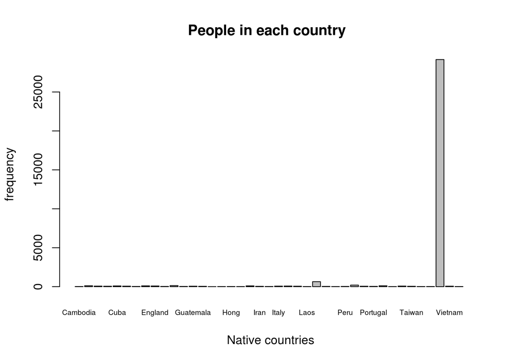

```r
counts <- table(unclean_data$native.country)
barplot(counts, main = "People in each country ", xlab = " Native countries", cex.names = 0.6, ylab = "frequency", )
```

## 8. Analysing column salaries

I rounded off the salary values to 2 decimal places

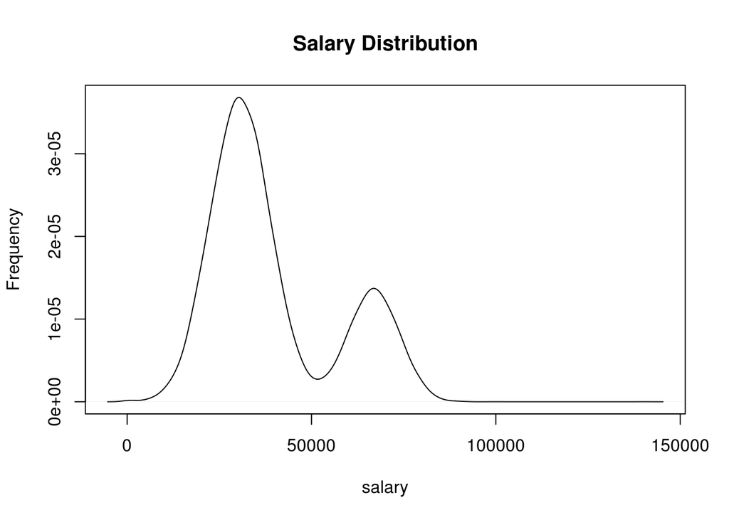

```r
unclean_data$salaries <- format(round(unclean_data$salaries, 2), nsmall = 2)
unclean_data$salaries <- as.numeric(unclean_data$salaries)

plot(density(unclean_data$salaries), main = "Salary Distribution",  xlab = "salary", ylab = "Frequency")
```

salary is a ratio.

## 10. Analysing column Male.

1 is used to denote males and there 21790 males

```r
data.frame(table(unclean_data$male))
```

| Var1 | Freq |
| --- | --- |
| 1 | 21790 |

## 11. Analysing Column Female

1 is used to analyse females and there 10771 females

```r
library(plyr, warn.conflicts = FALSE)

table(unclean_data$female)
```

```
##
##     1
## 10771
```

# Exercise 3

## a)

-I first grouped the data by occupation and education using the group by function

-I then calculated the average salary for each occupation using summarise function

```r
library(dplyr, warn.conflicts = FALSE)
library(ggplot2, warn.conflicts = FALSE)
library(tidyr, warn.conflicts = FALSE)
data.occupation.education  = group_by(unclean_data, occupation, education)
data.avg.sal               = summarise(data.occupation.education, average_salary=mean(salaries))
data.table <- spread(data.avg.sal, key=education, value=average_salary)
data.table
```

| occupation | 10th | 11th | 1st-4th | 5th-6th | 7th-8th | 9th | Assoc-acdm | Assoc-voc | Bachelors | Doctorate | HS-grad | Masters | Preschool | Prof-school | Some-college | <NA> |
| --- | --- | --- | --- | --- | --- | --- | --- | --- | --- | --- | --- | --- | --- | --- | --- | --- |
| Adm-clerical | 29957.97 | 29976.85 | NA | 26075.00 | 35226.91 | 32473.00 | 34836.39 | 33989.10 | 38987.47 | 43041.60 | 34729.64 | 42550.85 | 31927.50 | 44568.11 | 34387.94 | 29722.61 |
| Armed-Forces | NA | NA | NA | NA | NA | NA | NA | NA | 15014.00 | NA | 35544.00 | 67993.00 | NA | NA | 19421.00 | 48635.00 |
| Craft-repair | 35271.21 | 36050.30 | 32884.09 | 33559.63 | 33048.06 | 35322.85 | 41023.08 | 42391.51 | 45141.61 | 54458.50 | 38615.12 | 46957.59 | 33937.50 | 52143.71 | 41353.64 | 35800.19 |
| Exec-managerial | 38655.33 | 36805.44 | 50014.50 | 71742.00 | 42949.74 | 38819.62 | 46605.03 | 45784.69 | 50908.82 | 63967.98 | 42182.16 | 57455.88 | NA | 58638.12 | 43447.34 | 36365.31 |
| Farming-fishing | 32535.09 | 34774.05 | 31450.00 | 30814.36 | 33664.48 | 31886.18 | 32939.19 | 38431.48 | 39866.14 | 70039.00 | 35043.57 | 40793.10 | 32559.33 | 43915.50 | 33912.57 | 33999.88 |
| Handlers-cleaners | 32047.00 | 30906.23 | 31633.06 | 32748.47 | 30780.35 | 34131.20 | 33321.33 | 34322.86 | 37371.94 | NA | 32552.26 | 29983.00 | 30799.00 | NA | 32719.36 | 32224.45 |
| Machine-op-inspct | 32183.33 | 31165.66 | 32227.96 | 33421.93 | 33776.59 | 32178.88 | 43272.30 | 39073.59 | 38791.84 | 70502.00 | 35660.08 | 31144.50 | 32628.82 | 38026.00 | 36279.22 | 28159.49 |
| Other-service | 30484.64 | 31202.76 | 29770.65 | 31433.08 | 31001.63 | 31044.70 | 33145.14 | 33618.78 | 35861.41 | 71626.00 | 32137.30 | 32017.68 | 32498.47 | 37343.75 | 31471.02 | 31881.76 |
| Priv-house-serv | 33172.00 | 27458.43 | 25066.36 | 26133.07 | 28921.25 | 33230.20 | 16753.50 | 34781.25 | 37750.43 | NA | 31240.14 | 28568.00 | 26577.00 | NA | 31587.56 | 34069.25 |
| Prof-specialty | 45071.67 | 30745.05 | 23128.50 | 39091.00 | 28300.22 | 35095.00 | 40030.98 | 42809.15 | 44600.97 | 56764.62 | 40999.92 | 48030.88 | 34861.00 | 58333.60 | 40584.20 | 37524.00 |

[output cut: 5 more lines]

## b

```r
data.long <- gather(data.table, education, AvgSalary, "10th":"Some-college")
data.long
```

| occupation | <NA> | education | AvgSalary |
| --- | --- | --- | --- |
| Adm-clerical | 29722.61 | 10th | 29957.97 |
| Armed-Forces | 48635.00 | 10th | NA |
| Craft-repair | 35800.19 | 10th | 35271.21 |
| Exec-managerial | 36365.31 | 10th | 38655.33 |
| Farming-fishing | 33999.88 | 10th | 32535.09 |
| Handlers-cleaners | 32224.45 | 10th | 32047.00 |
| Machine-op-inspct | 28159.49 | 10th | 32183.33 |
| Other-service | 31881.76 | 10th | 30484.64 |
| Priv-house-serv | 34069.25 | 10th | 33172.00 |
| Prof-specialty | 37524.00 | 10th | 45071.67 |

[output cut: 215 more lines]

## c)

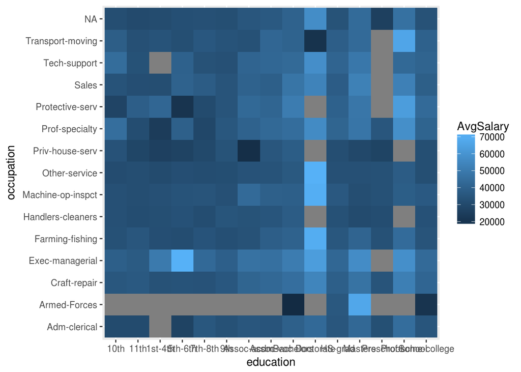

```r
library(ggplot2, warn.conflicts = FALSE)

ggplot(data.long,  aes(x=education, y=occupation)) +  geom_tile(aes(x=education, y=occupation, fill=AvgSalary))
```

## d)

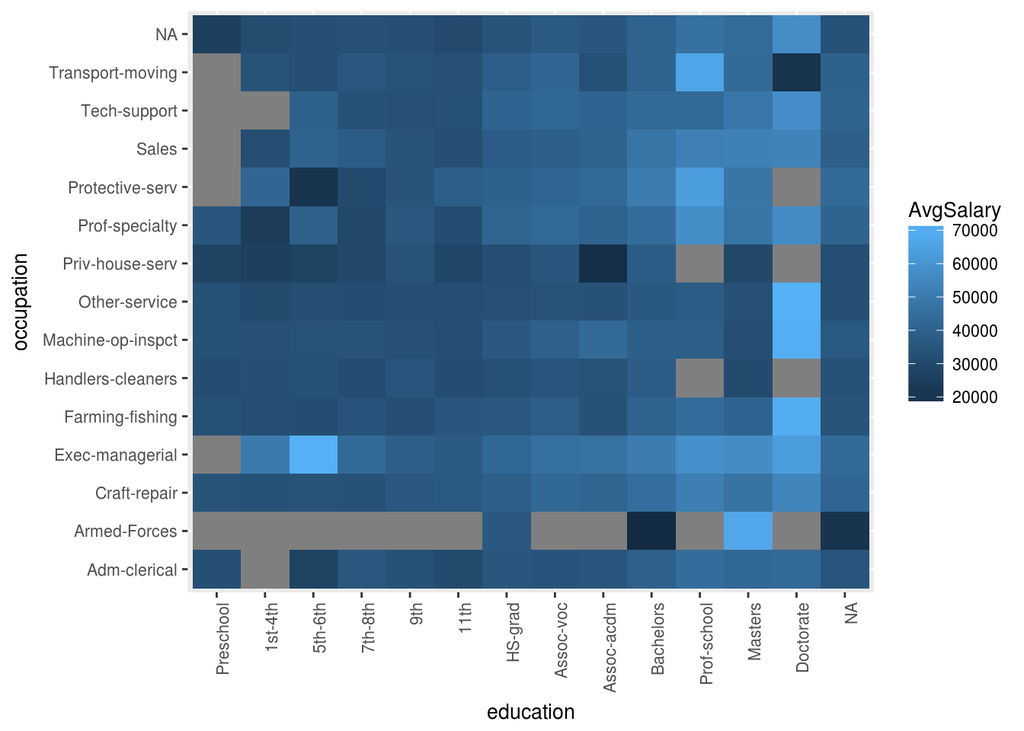

```r
#data <- data.frame(lapply(data.long, factor))


data.long$education <- factor(data.long$education, levels = c("Preschool", "1st-4th", "5th-6th", "7th-8th", "9th", "11th", "12th", "HS-grad", "Assoc-voc",  "Assoc-acdm", "levels",
                                                          "Bachelors", "Prof-school", "Masters", "Doctorate" ) , ordered = TRUE)


ggplot(data.long,  aes(x=education, y=occupation)) +  geom_tile(aes(x=education, y=occupation, fill=AvgSalary)) +theme(text = element_text(size=10),
        axis.text.x = element_text(angle=90, hjust=1))
```

## e) List 3 interesting facts that you can read out from this plot.

-Those who ended in preschool can not work in armed forses, protective services, sales, Tech-suppor and transport. -Those who have masters they atlest everyone has a job.

## f) Create another plot of this dataset that you think conveys interesting information

I first grouped the data by occupation and the i computed the average salary of each occupation using mean function

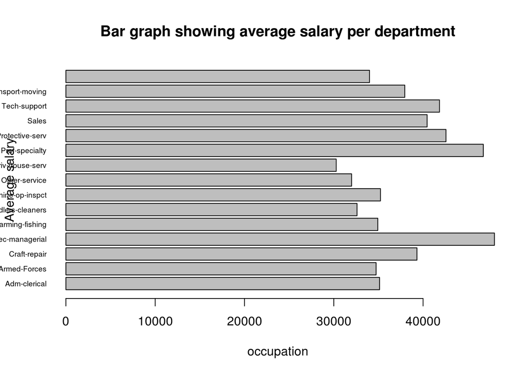

```r
grouped_data <- group_by(unclean_data, occupation)
summ_data <- summarise(grouped_data, AvgSalary=mean(salaries))
barplot(summ_data$AvgSalary, names.arg=summ_data$occupation, horiz = TRUE, las=1, cex.names = 0.6, xlab = "occupation", ylab = "Average salary", main = "Bar graph showing average salary per department")
```